# BCB420 Assignment 1 - Dataset Selection and Initial Processing

Arianne Beauregard

### Loading required libraries

```r
library(GEOquery)
library(knitr)
library(kableExtra)
library(edgeR)
library(org.Hs.eg.db)
```

## Dataset

The dataset of interest is from a study of lipid remodeling in response to methionine stress in triple-negative breast cancer (TNBC) cells (Borrego et al., 2021). The dataset contains RNA profiles of two TNBC cell lines, one methionine-sensitive cell line (MDA-MBA-468) its methionine-insensitive derivative (MDA-MB-468res-R8), responding to methionine stress.

### Downloading Data

We will first download and get information on the dataset using the package GEOquery. The dataset is from GEO Accession GSE155955. We are interested in the third file, GSE155955_RAW_gene_count_matrix.csv.gz.

```r
# description of dataset
gse <- getGEO("GSE155955", GSEMatrix = FALSE)
contact_info <- data.frame(head(Meta(gse)))
colnames(contact_info) <- c("Address", "City", "Country", "Email", "Institute", "Name")
kable(contact_info, format = "html", caption = "Contact Information") %>%
  kable_styling()
```

Contact Information

| Address | City | Country | Email | Institute | Name |
| --- | --- | --- | --- | --- | --- |
| Department of Biological Chemistry, 829 Health Sciences Rd | Irvine | USA | pkaiser@uci.edu | University of California, Irvine | Peter,,Kaiser |

```r
# information about platform
current_gpl <- names(GPLList(gse))[1]
current_gpl_info <- Meta(getGEO(current_gpl))
cat(paste0("Platform information:\n", "Title: ",  current_gpl_info$title, "\nLast updated: ", current_gpl_info$last_update_date, "\nOrganisim: ", current_gpl_info$organism))
```

```
Platform information:
Title: Illumina HiSeq 4000 (Homo sapiens)
Last updated: Mar 21 2019
Organisim: Homo sapiens
```

```r
# getting supplementary files
sfiles <- getGEOSuppFiles('GSE155955')
fnames <- rownames(sfiles)

# we want the 3rd file
exp <- read.csv(fnames[3],header=TRUE,
                check.names = FALSE)

kable(exp[1:15,1:7], format = "html", caption = "Head of GSE155955 Dataset") %>%
  kable_styling()
```

Head of GSE155955 Dataset

|  | SYMBOL | ENTREZID | MB468_000_01 | MB468_000_02 | MB468_000_03 | R8_000_01 |
| --- | --- | --- | --- | --- | --- | --- |
| 1 | A1BG | 1 | 17 | 14 | 10 | 16 |
| 2 | A1BG-AS1 | 503538 | 13 | 15 | 7 | 20 |
| 3 | A1CF | 29974 | 0 | 1 | 2 | 1 |
| 4 | A2M | 2 | 956 | 1290 | 768 | 150 |
| 5 | A2M-AS1 | 144571 | 9 | 10 | 3 | 5 |
| 6 | A2ML1 | 144568 | 8 | 19 | 8 | 55 |
| 7 | A2MP1 | 3 | 0 | 0 | 0 | 0 |
| 8 | A3GALT2 | 127550 | 0 | 0 | 0 | 0 |
| 9 | A4GALT | 53947 | 16 | 35 | 20 | 10 |
| 10 | A4GNT | 51146 | 2 | 0 | 0 | 1 |
| 11 | AA06 | 100506677 | 0 | 0 | 0 | 0 |
| 12 | AAAS | 8086 | 1147 | 1295 | 703 | 1316 |
| 13 | AACS | 65985 | 2358 | 2781 | 1571 | 2099 |
| 14 | AACSP1 | 729522 | 2 | 2 | 1 | 1 |
| 15 | AADAC | 13 | 0 | 0 | 0 | 0 |

### Overview of Data

Next, we will get an overview of the data. There are 26737 genes and 24 samples. There are no missing values in the gene count data.

```r
# checking number of genes(rows) and samples (columns - 3)
dim(exp)
```

```
[1] 26737    27
```

```r
# check for missing values
sum(is.na(exp[4:27]))
```

```
[1] 0
```

### Defining Groups

There are two different cell lines (MDA-MB-468 and MDA-MB-468res-R8), measured at 4 different hourly timepoints (0h, 0.5h, 2h, 12h) during methionine stress. Methionine stress was added by providing homocysteine instead of methionine in the cell lines’ growth media. There are 3 replicates for each cell line.

```r
# define groups
colnames(exp)
```

```
 [1] ""             "SYMBOL"       "ENTREZID"     "MB468_000_01" "MB468_000_02" "MB468_000_03" "R8_000_01"
 [8] "R8_000_02"    "R8_000_03"    "MB468_030_01" "MB468_030_02" "MB468_030_03" "R8_030_01"    "R8_030_02"
[15] "R8_030_03"    "MB468_120_01" "MB468_120_02" "MB468_120_03" "R8_120_01"    "R8_120_02"    "R8_120_03"
[22] "MB468_720_01" "MB468_720_02" "MB468_720_03" "R8_720_01"    "R8_720_02"    "R8_720_03"
```

```r
samples <- data.frame(lapply(colnames(exp)[4:27],
        FUN=function(x){unlist(strsplit(x,
                        split = "_"))}))
colnames(samples) <- colnames(exp)[4:27]
rownames(samples) <- c("cell.line","timepoint", "replicate")
samples <- data.frame(t(samples))
kable(samples, caption = "Sample Groups", col.names = c("Cell Line", "Timepoint (min)", "Replicate")) %>%
  kable_styling()
```

Sample Groups

|  | Cell Line | Timepoint (min) | Replicate |
| --- | --- | --- | --- |
| MB468_000_01 | MB468 | 000 | 01 |
| MB468_000_02 | MB468 | 000 | 02 |
| MB468_000_03 | MB468 | 000 | 03 |
| R8_000_01 | R8 | 000 | 01 |
| R8_000_02 | R8 | 000 | 02 |
| R8_000_03 | R8 | 000 | 03 |
| MB468_030_01 | MB468 | 030 | 01 |
| MB468_030_02 | MB468 | 030 | 02 |
| MB468_030_03 | MB468 | 030 | 03 |
| R8_030_01 | R8 | 030 | 01 |
| R8_030_02 | R8 | 030 | 02 |
| R8_030_03 | R8 | 030 | 03 |
| MB468_120_01 | MB468 | 120 | 01 |
| MB468_120_02 | MB468 | 120 | 02 |
| MB468_120_03 | MB468 | 120 | 03 |
| R8_120_01 | R8 | 120 | 01 |
| R8_120_02 | R8 | 120 | 02 |
| R8_120_03 | R8 | 120 | 03 |
| MB468_720_01 | MB468 | 720 | 01 |
| MB468_720_02 | MB468 | 720 | 02 |
| MB468_720_03 | MB468 | 720 | 03 |
| R8_720_01 | R8 | 720 | 01 |
| R8_720_02 | R8 | 720 | 02 |
| R8_720_03 | R8 | 720 | 03 |

### Duplicated Genes

We will check if there are any duplicate genes. There are 4 repeated gene symbols, HBD, MEMO1, MMD2 and TEC.

```r
summarized_gene_counts <- sort(table(exp$SYMBOL),
                               decreasing = TRUE)

kable(summarized_gene_counts[
  which(summarized_gene_counts>1)[1:5]],
  format="html", caption = "Frequency of Duplicate Genes", col.names = c("Gene Symbol", "Frequency")) %>%
  kable_styling(full_width = FALSE, position = "left")
```

Frequency of Duplicate Genes

| Gene Symbol | Frequency |
| --- | --- |
| HBD | 2 |
| MEMO1 | 2 |
| MMD2 | 2 |
| TEC | 2 |
| NA | NA |

### Filtering Low Counts

Next, we filter out genes with low counts using the cpm (counts per million) function from the package edgeR. After filtering, we have 13113 genes, 49% of the original dataset.

```r
# translate out counts into counts per million using the edgeR package function cpm
cpms <- cpm(as.matrix(exp[, 4:27]))
rownames(cpms) <- exp[,1]
# get rid of low counts
keep <- rowSums(cpms >1) >= 8
exp_filtered <- exp[keep,]

dim(exp_filtered)
```

```
[1] 13113    27
```

```r
# proportion of genes remaing after filtering
dim(exp_filtered)[1] / dim(exp)[1]
```

```
[1] 0.490444
```

There are still 2 duplicated genes, MEMO1 and TEC. In the dataset, they have different Entrez IDs. From looking on NCBI, they are different genes. In both cases, the primary source of one of the duplicates is HGNC (with HUGO symbol), while the primary source of the other is OMIM (with no HUGO symbol associated). Because of this, we will map the genes to both HUGO symbols (if available) and Entrez IDs, to have 2 layers of identification.

```r
# checking if there are repeats
summarized_gene_counts_filtered <- sort(table(exp_filtered$SYMBOL),
                                        decreasing = TRUE)


kable(summarized_gene_counts_filtered[
  which(summarized_gene_counts_filtered>1)[1:5]],
  format="html", caption = "Frequency of Duplicate Genes after Filtering", col.names = c("Gene Symbol", "Frequency")) %>%
  kable_styling(full_width = FALSE, position = "left")
```

Frequency of Duplicate Genes after Filtering

| Gene Symbol | Frequency |
| --- | --- |
| MEMO1 | 2 |
| TEC | 2 |
| NA | NA |
| NA | NA |
| NA | NA |

```r
dup_symbols <- names(summarized_gene_counts_filtered[which(summarized_gene_counts_filtered>1)])

kable(exp_filtered[exp_filtered$SYMBOL %in% dup_symbols, c("SYMBOL", "ENTREZID")], format="html", row.names = FALSE, caption = "Duplicate Genes", col.names = c("Gene Symbol", "Entrez ID")) %>%
  kable_styling(full_width = FALSE, position = "left")
```

Duplicate Genes

| Gene Symbol | Entrez ID |
| --- | --- |
| MEMO1 | 7795 |
| MEMO1 | 51072 |
| TEC | 7006 |
| TEC | 100124696 |

## Identifier Mapping

### Mapping from Gene Symbols to Entrez IDs

The data contains both gene symbols and Entrez IDs. Not all the Entrez IDs are available in the dataset. We will first map the genes to Entrez IDs for those that are missing. The org.Hs.eg.db package contains genome wide annotation for humans, primarily based on mapping using Entrez Gene identifiers. This package will be used to map from gene symbols to Entrez IDs.

```r
# first select rows that have no entrezid
missing_entrez <- exp_filtered[is.na(exp_filtered$ENTREZID), "SYMBOL"]

# using keytype ALIAS to cover all
# tried using keytype SYMBOL, but returned Entrez ID for only one gene
alias_to_entrez <- select(org.Hs.eg.db, keys=missing_entrez, columns="ENTREZID", keytype="ALIAS")

# for genes that returned multiple entrezids, unable to tell which is correct id
# will leave all entrez ids (concatenated by ", ")
alias_to_entrez_concat <- aggregate(ENTREZID ~ ALIAS, data = alias_to_entrez, paste, collapse = ", ")

# add entrez ids to exp_filtered
for (i in seq_along(alias_to_entrez_concat$ALIAS)){
  gene <- alias_to_entrez_concat$ALIAS[i]
  entrez <- alias_to_entrez_concat$ENTREZID[i]
  exp_filtered[exp_filtered$SYMBOL == gene, "ENTREZID"] <- entrez
}
```

Before mapping to HUGO symbols, we will first check the exceptions; genes still missing Entrez IDs and genes with multiple Entrez IDs.

#### Genes not mapped to Entrez IDs

Among the genes without Entrez IDs, There are 47 gene symbols starting with “LOC”. These are genes on NCBI where a published symbol is not available, and orthologs have not yet been determined. The symbols are constructed as ‘LOC’ + the Entrez ID. We will set the Entrez ID to be the numerical part of the the symbol (part after “LOC”).

There are 35 gene symbols starting with “ERCC-” with no Entrez ID. These are from ERCC RNA Spike-In mix controls, a set of external RNA controls developed by the External RNA Controls Consortium (ERCC). We wil leave the Entrez IDs for these as NA, and retain their symbols.

This leaves us with 8 gene symbols with missing Entrez IDs. We will manually map these to their Entrez IDs and HUGO symbols. Results were found on Harmonizome and NCBI.

```r
# find symbols still missing entrez (90)
missing_entrez <- exp_filtered[is.na(exp_filtered$ENTREZID), "SYMBOL"]

# LOC genes -> SYMBOL - "LOC" for entrez id
exp_filtered$ENTREZID <- ifelse(grepl("^LOC", exp_filtered$SYMBOL) & is.na(exp_filtered$ENTREZID), gsub("LOC", "", exp_filtered$SYMBOL), exp_filtered$ENTREZID)

# still missing (43)
missing_entrez <- exp_filtered[is.na(exp_filtered$ENTREZID), "SYMBOL"]

# remove ERCC-
missing_entrez <- missing_entrez[!grepl("^ERCC-", missing_entrez)]

# show remaining genes with missing entrez
missing_entrez
```

```
[1] "FLJ10038" "FLJ23867" "FLJ41200" "FLJ43879" "KIAA1804" "MGC39584" "MGC72080" "MIR6723"
```

```r
# manual mapping for 8 remaining missing
exp_filtered$ENTREZID[exp_filtered$SYMBOL == "FLJ10038"] <- 55056
exp_filtered$ENTREZID[exp_filtered$SYMBOL == "FLJ23867"] <- 5768
exp_filtered$ENTREZID[exp_filtered$SYMBOL == "FLJ41200"] <- 401492
exp_filtered$ENTREZID[exp_filtered$SYMBOL == "FLJ43879"] <- 401039
exp_filtered$ENTREZID[exp_filtered$SYMBOL == "KIAA1804"] <- 84451
exp_filtered$ENTREZID[exp_filtered$SYMBOL == "MGC39584"] <- 441058
exp_filtered$ENTREZID[exp_filtered$SYMBOL == "MGC72080"] <- 389538

# correct HGNC symbol, record is discontinued, no new record
exp_filtered$ENTREZID[exp_filtered$SYMBOL == "MIR6723"] <- 102465432
```

#### Genes mapped to multiple Entrez IDs

Next, we will look at the genes with multiple Entrez IDs. There are 14 genes that were mapped to multiple Entrez IDs. We will manually map these to their Entrez IDs and HUGO symbols. Results were found on Harmonizome and NCBI.

```r
multiple_entrez <- missing_entrez <- exp_filtered[grepl(", ", exp_filtered$ENTREZID), ]
kable(multiple_entrez[, c("SYMBOL", "ENTREZID")], caption = "Genes Symbols mapped to Multiple Entrez IDs",
      col.names = c("Gene Symbol", "Entrez IDs")) %>%
  kable_styling(full_width = FALSE, position = "left")
```

Genes Symbols mapped to Multiple Entrez IDs

|  | Gene Symbol | Entrez IDs |
| --- | --- | --- |
| 533 | AIM1 | 202, 9212, 51151 |
| 949 | APITD1 | 378708, 100526739 |
| 1950 | C10orf2 | 56652, 57132 |
| 2276 | C2orf47 | 51614, 79568 |
| 4236 | CSRP2BP | 57325, 100303755 |
| 5487 | EFTUD1 | 1997, 79631 |
| 6293 | FAM21A | 253725, 387680 |
| 8425 | HN1 | 51155, 100462977 |
| 8426 | HN1L | 57585, 90861 |
| 16346 | NAT6 | 3373, 24142 |
| 16795 | NOTCH2NL | 388677, 100996717, 100996763 |
| 21325 | SHFM1 | 1749, 7979 |
| 21665 | SLC35E2 | 9906, 728661 |
| 23110 | STRA13 | 8553, 201254 |

```r
exp_filtered$ENTREZID[exp_filtered$SYMBOL == "AIM1"] <- 202
exp_filtered$ENTREZID[exp_filtered$SYMBOL == "APITD1"] <- 378708
exp_filtered$ENTREZID[exp_filtered$SYMBOL == "C10orf2"] <- 56652
exp_filtered$ENTREZID[exp_filtered$SYMBOL == "C2orf47"] <- 79568
exp_filtered$ENTREZID[exp_filtered$SYMBOL == "CSRP2BP"] <- 57325
exp_filtered$ENTREZID[exp_filtered$SYMBOL == "EFTUD1"] <- 79631
exp_filtered$ENTREZID[exp_filtered$SYMBOL == "FAM21A"] <- 387680
exp_filtered$ENTREZID[exp_filtered$SYMBOL == "HN1"] <- 51155
exp_filtered$ENTREZID[exp_filtered$SYMBOL == "HN1L"] <- 90861
exp_filtered$ENTREZID[exp_filtered$SYMBOL == "NAT6"] <- 24142 # NAA80
exp_filtered$ENTREZID[exp_filtered$SYMBOL == "NOTCH2NL"] <- 388677
exp_filtered$ENTREZID[exp_filtered$SYMBOL == "SHFM1"] <- 7979
exp_filtered$ENTREZID[exp_filtered$SYMBOL == "SLC35E2"] <- 9906
exp_filtered$ENTREZID[exp_filtered$SYMBOL == "STRA13"] <- 201254
```

### Mapping from Entrez IDs to HUGO Symbols

Next, we will map the Entrez IDs to their HUGO symbols, using the org.Hs.eg.db package.

```r
entrez_to_symbol <- select(org.Hs.eg.db, keys=exp_filtered$ENTREZID, columns="SYMBOL", keytype="ENTREZID")

to_check <- data.frame(matrix(nrow = 0, ncol = 2))
colnames(to_check) <- c("SYMBOL", "ENTREZID")

# row order is retained, change the ones that are different
for (i in seq_along(entrez_to_symbol$SYMBOL)) {
  new_symbol <- entrez_to_symbol$SYMBOL[i]
  if (is.na(new_symbol)) {
    # add to dataframe to check
    to_check[nrow(to_check) + 1, ] <- list(exp_filtered$SYMBOL[i], exp_filtered$ENTREZID[i])
  } else if (new_symbol != exp_filtered$SYMBOL[i]) {
    exp_filtered$SYMBOL[i] <- new_symbol
  } else {
    # no change, correct symbol
    ;
  }
}
```

### Outliers

We will manually check the remaining genes that did not map to any symbol. 19 out of the 21 genes were discontinued on NCBI. These were replaced with new gene IDs and symbols. 2 genes were discontinued and not replaced from NCBI, CRIPAK and MIR6723; we will leave these as is.

```r
# ignore all genes starting ERCC- (RNA controls)
to_check <- to_check[!grepl("^ERCC-", to_check$SYMBOL), ]
kable(to_check, row.names = FALSE, col.names = c("Gene Symbol", "Entrez ID")) %>%
  kable_styling()
```

| Gene Symbol | Entrez ID |
| --- | --- |
| C2orf48 | 348738 |
| CRIPAK | 285464 |
| KIAA0754 | 643314 |
| KIAA1107 | 23285 |
| LINC01279 | 100506621 |
| LOC100130093 | 100130093 |
| LOC100130899 | 100130899 |
| LOC100133331 | 100133331 |
| LOC100506548 | 100506548 |
| LOC100507577 | 100507577 |
| LOC101927181 | 101927181 |
| LOC101929613 | 101929613 |
| LOC102723703 | 102723703 |
| LOC103611081 | 103611081 |
| LOC105376575 | 105376575 |
| LOC90784 | 90784 |
| MGC27345 | 157247 |
| MICALCL | 84953 |
| MIR6723 | 102465432 |
| PALM2 | 114299 |
| TNRC6C-AS1 | 100131096 |

```r
# Withdrawn genes: CRIPAK, MIR6723

# discontinued, replace with new gene id
exp_filtered$SYMBOL[exp_filtered$SYMBOL == "C2orf48"] <- "RRM2"
exp_filtered$ENTREZID[exp_filtered$SYMBOL == "RRM2"] <- 6241
exp_filtered$SYMBOL[exp_filtered$SYMBOL == "KIAA0754"] <- "MACF1"
exp_filtered$ENTREZID[exp_filtered$SYMBOL == "MACF1"] <- 23499
exp_filtered$SYMBOL[exp_filtered$SYMBOL == "KIAA1107"] <- "BTBD8"
exp_filtered$ENTREZID[exp_filtered$SYMBOL == "BTBD8"] <- 284697
exp_filtered$SYMBOL[exp_filtered$SYMBOL == "LINC01279"] <- "CCDC80"
exp_filtered$ENTREZID[exp_filtered$SYMBOL == "CCDC80"] <- 151887
exp_filtered$SYMBOL[exp_filtered$SYMBOL == "LOC100130093"] <- "SNAP47"
exp_filtered$ENTREZID[exp_filtered$SYMBOL == "SNAP47"] <- 116841
exp_filtered$SYMBOL[exp_filtered$SYMBOL == "LOC100130899"] <- "FAM83F"
exp_filtered$ENTREZID[exp_filtered$SYMBOL == "FAM83F"] <- 113828
exp_filtered$SYMBOL[exp_filtered$SYMBOL == "LOC100133331"] <- "LOC100288069"
exp_filtered$ENTREZID[exp_filtered$SYMBOL == "LOC100288069"] <- 100288069
exp_filtered$SYMBOL[exp_filtered$SYMBOL == "LOC100506548"] <- "RPL37"
exp_filtered$ENTREZID[exp_filtered$SYMBOL == "RPL37"] <- 6167
exp_filtered$SYMBOL[exp_filtered$SYMBOL == "LOC100507577"] <- "LONP2"
exp_filtered$ENTREZID[exp_filtered$SYMBOL == "LONP2"] <- 83752
exp_filtered$SYMBOL[exp_filtered$SYMBOL == "LOC101927181"] <- "CHST12"
exp_filtered$ENTREZID[exp_filtered$SYMBOL == "CHST12"] <- 55501
exp_filtered$SYMBOL[exp_filtered$SYMBOL == "LOC101929613"] <- "GREP1"
exp_filtered$ENTREZID[exp_filtered$SYMBOL == "GREP1"] <- 283875
exp_filtered$SYMBOL[exp_filtered$SYMBOL == "LOC102723703"] <- "TSPAN14"
exp_filtered$ENTREZID[exp_filtered$SYMBOL == "TSPAN14"] <- 81619
exp_filtered$SYMBOL[exp_filtered$SYMBOL == "LOC103611081"] <- "SNX19"
exp_filtered$ENTREZID[exp_filtered$SYMBOL == "SNX19"] <- 399979
exp_filtered$SYMBOL[exp_filtered$SYMBOL == "LOC105376575"] <- "NUCB2"
exp_filtered$ENTREZID[exp_filtered$SYMBOL == "NUCB2"] <- 4925
exp_filtered$SYMBOL[exp_filtered$SYMBOL == "LOC90784"] <- "POLR1A"
exp_filtered$ENTREZID[exp_filtered$SYMBOL == "POLR1A"] <- 25885
exp_filtered$SYMBOL[exp_filtered$SYMBOL == "MGC27345"] <- "RBM28"
exp_filtered$ENTREZID[exp_filtered$SYMBOL == "RBM28"] <- 55131
exp_filtered$SYMBOL[exp_filtered$SYMBOL == "MICALCL"] <- "MICAL2"
exp_filtered$ENTREZID[exp_filtered$SYMBOL == "MICAL2"] <- 9645
exp_filtered$SYMBOL[exp_filtered$SYMBOL == "PALM2"] <- "PALM2AKAP2"
exp_filtered$ENTREZID[exp_filtered$SYMBOL == "PALM2AKAP2"] <- 445815
exp_filtered$SYMBOL[exp_filtered$SYMBOL == "TNRC6C-AS1"] <- "TMC6"
exp_filtered$ENTREZID[exp_filtered$SYMBOL == "TMC6"] <- 11322
```

### Duplicated genes

Now that identifier mapping is done, we will check if there are duplicated genes. There are now 21 duplicated genes. These include the 2 from earlier (MEMO1 and TEC), and 19 new ones. There are new duplicated genes are because the different symbols actually mapped to the same gene, once replacing all discontinued ones.

```r
summarized_gene_counts_filtered <- sort(table(exp_filtered$SYMBOL),
                               decreasing = TRUE)

kable(summarized_gene_counts_filtered[
  which(summarized_gene_counts_filtered>1)[1:25]],
  format="html", caption = "Frequency of Duplicate Genes after Filtering and ID Mapping", col.names = c("Gene Symbol", "Frequency")) %>%
  kable_styling(full_width = FALSE, position = "left")
```

Frequency of Duplicate Genes after Filtering and ID Mapping

| Gene Symbol | Frequency |
| --- | --- |
| CCDC80 | 2 |
| CHST12 | 2 |
| FAM83F | 2 |
| GREP1 | 2 |
| LCOR | 2 |
| LONP2 | 2 |
| MACF1 | 2 |
| MEMO1 | 2 |
| MICAL2 | 2 |
| NUCB2 | 2 |
| POLR1A | 2 |
| QSOX1 | 2 |
| RBM28 | 2 |
| RPL37 | 2 |
| RRM2 | 2 |
| SNAP47 | 2 |
| SNX19 | 2 |
| SYNE3 | 2 |
| TEC | 2 |
| TMC6 | 2 |
| TSPAN14 | 2 |
| NA | NA |
| NA | NA |
| NA | NA |
| NA | NA |

## Normalization

We will look at the distribution of the data. We will visualize this through a boxplot and density plot.

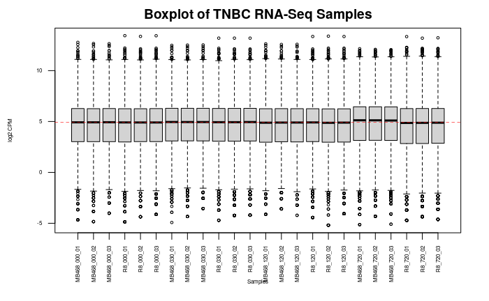

```r
# distribution (box plot)
data2plot <- log2(cpm(exp_filtered[,4:27]))
boxplot(data2plot, xlab = "Samples", ylab = "log2 CPM",
        las = 2, cex = 0.5, cex.lab = 0.5,
        cex.axis = 0.5, main = "Boxplot of TNBC RNA-Seq Samples")
# draw the median on each box plot
abline(h = median(apply(data2plot, 2, median)),
       col = "red", lwd = 0.6, lty = "dashed")
```

```r
# density plot
counts_density <- apply(log2(cpm(exp_filtered[,4:27])),
                        2, density)
  # calculate the limits across all the samples
    xlim <- 0; ylim <- 0
    for (i in 1:length(counts_density)) {
      xlim <- range(c(xlim, counts_density[[i]]$x));
      ylim <- range(c(ylim, counts_density[[i]]$y))
    }
    cols <- rainbow(length(counts_density))
    ltys <- rep(1, length(counts_density))
    # plot the first density plot to initialize the plot
    plot(counts_density[[1]], xlim=xlim, ylim=ylim, type="n",
         ylab="Smoothing density of log2-CPM",
         main="Density plot of TNBC RNA-Seq Samples", cex.lab = 0.85)
    # plot each line
    for (i in 1:length(counts_density))
      lines(counts_density[[i]], col=cols[i], lty=ltys[i])
```

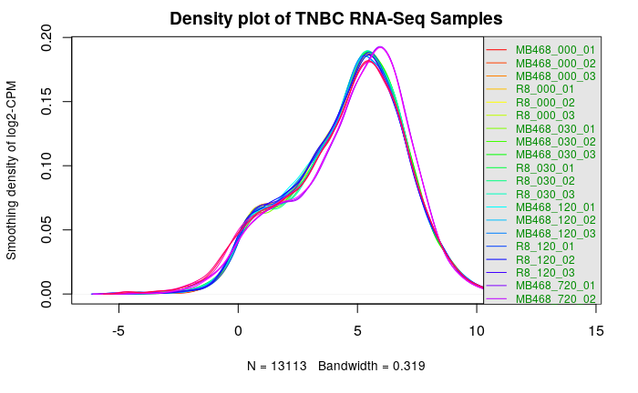

```r
    # create legend
    legend("topright", colnames(data2plot),
           col=cols, lty=ltys, cex=0.75,
           border ="blue",  text.col = "green4",
           merge = TRUE, bg = "gray90")
```

### Normalization Method

Our data contains ERCC RNA Spike-In mix controls, which are a set of synthetic RNAs that act as controls. We can use conventional normalization methods (Evans et al., 2018). We will use Trimmed Mean of M-values (TMM) on our dataset. edgeR normalization

```r
# groups are cell line + timepoint
groups <- mapply(paste, samples$cell.line, samples$timepoint)

# prepare matrix of data
filtered_data_matrix <- as.matrix(exp_filtered[,4:27])
rownames(filtered_data_matrix) <- exp_filtered$SYMBOL
d <- DGEList(counts=filtered_data_matrix, group=groups)

# TMM to calculate norm factors
d <- calcNormFactors(d, method = "TMM")

# normalize counts
norm_counts <- cpm(d, log = TRUE)

# extract spike norms and raw norms
spike_norm_counts <- norm_counts[grepl("^ERCC-", row.names(norm_counts)), ]
raw_norm_counts <- norm_counts[!grepl("^ERCC-", row.names(norm_counts)), ]

# calculate the scaling factor
scaling_factor <- mean(rowSums(raw_norm_counts)) / mean(rowSums(spike_norm_counts))

# apply the scaling factor to the raw norm counts
normalized_counts <- raw_norm_counts * scaling_factor
```

We will visualize the distribution of our normalized data.

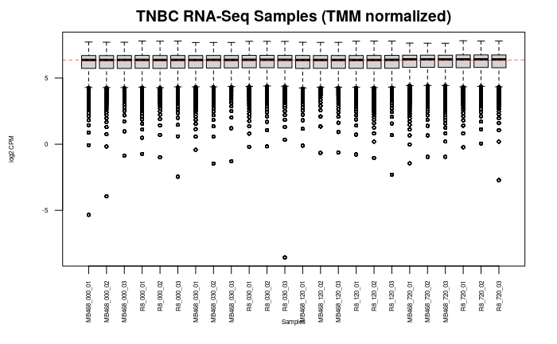

```r
# plot normalized
# distribution (box plot)
data2plot <- log2(cpm(normalized_counts))
boxplot(data2plot, xlab = "Samples", ylab = "log2 CPM",
        las = 2, cex = 0.5, cex.lab = 0.5,
        cex.axis = 0.5, main = "TNBC RNA-Seq Samples (TMM normalized)")
# draw the median on each box plot
abline(h = median(apply(data2plot, 2, median, na.rm = TRUE)),
       col = "red", lwd = 0.6, lty = "dashed")
```

```r
# density plot
counts_density <- apply(log2(cpm(normalized_counts)),
                        2, density, na.rm = TRUE)
  # calculate the limits across all the samples
    xlim <- 0; ylim <- 0
    for (i in 1:length(counts_density)) {
      xlim <- range(c(xlim, counts_density[[i]]$x));
      ylim <- range(c(ylim, counts_density[[i]]$y))
    }
    cols <- rainbow(length(counts_density))
    ltys <- rep(1, length(counts_density))
    # plot the first density plot to initialize the plot
    plot(counts_density[[1]], xlim=xlim, ylim=ylim, type="n",
         ylab="Smoothing density of log2-CPM",
         main="Density plot of TNBC RNA-Seq Samples (TMM normalized)", cex.lab = 0.85)
    # plot each line
    for (i in 1:length(counts_density))
      lines(counts_density[[i]], col=cols[i], lty=ltys[i])
```

[figure not shown]

```r
    # create legend
    legend("topright", colnames(data2plot),
           col=cols, lty=ltys, cex=0.75,
           border ="blue",  text.col = "green4",
           merge = TRUE, bg = "gray90")
```

The sample separation is visualized below in a multidimensional scaling plot. The distance between each pair of points correlates to the dissimilarity between the two samples. The cell line MDA-MBA-468 is shown in green, while the cell line MDA-MB-468res-R8 is shown in blue. As shown in the plot, the two cell lines are relatively dissimilar.

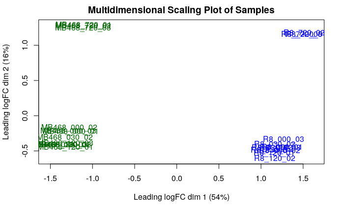

```r
plotMDS(d, labels=rownames(samples),
  col = c("darkgreen","blue")[factor(samples$cell.line)], main = "Multidimensional Scaling Plot of Samples")
```

## Dispersion

Finally, we will look at the dispersion of our data. We visualize the biological coefficient of variation (BCV) and the mean-variance relationship in the plots below.

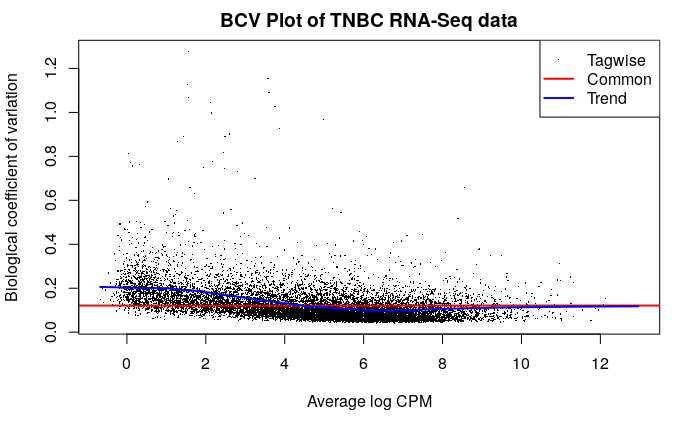

```r
model_design <- model.matrix(~samples$cell.line
                             + samples$timepoint)
d <- estimateDisp(d, model_design)
invisible(plotBCV(d, col.tagwise = "black", col.common = "red", main = "BCV Plot of TNBC RNA-Seq data"))
```

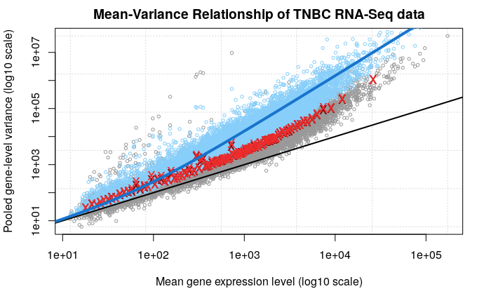

```r
# mean variance relationship
plotMeanVar(d, show.raw.vars = TRUE,
            show.tagwise.vars=TRUE,
            NBline=TRUE, show.ave.raw.vars = TRUE,
            show.binned.common.disp.vars = TRUE,
            main = "Mean-Variance Relationship of TNBC RNA-Seq data")
```

### References

- Andrew D. Rouillard, Gregory W. Gundersen, Nicolas F. Fernandez, Zichen Wang, Caroline D. Monteiro, Michael G. McDermott, Avi Ma’ayan, The harmonizome: a collection of processed datasets gathered to serve and mine knowledge about genes and proteins, Database, Volume 2016, 2016, baw100, https://doi.org/10.1093/database/baw100
- Borrego, S. L., Fahrmann, J., Hou, J., Lin, D. W., Tromberg, B. J., Fiehn, O., & Kaiser, P. (2021). Lipid remodeling in response to methionine stress in MDA-MBA-468 triple-negative breast cancer cells. Journal of lipid research, 62, 100056. https://doi.org/10.1016/j.jlr.2021.100056
- Evans C, Hardin J, Stoebel DM. Selecting between-sample RNA-Seq normalization methods from the perspective of their assumptions. Brief Bioinform. 2018 Sep 28;19(5):776-792. doi: 10.1093/bib/bbx008. PMID: 28334202; PMCID: PMC6171491. (for selecting normalization)
- National Center for Biotechnology Information (NCBI)[Internet]. Bethesda (MD): National Library of Medicine (US), National Center for Biotechnology Information; [1988] – [cited 2017 Apr 06]. Available from: https://www.ncbi.nlm.nih.gov/